# W03-1: Reflection on Regression and Ch5 (Spending Our Data)

- Show All Code
- Hide All Code
- View Source

Author

Luis Berimen

Published

June 23, 2026

# 1 Step 1-1: Regression Fundamentals

## 1.1 What is the goal of linear regression and why do we call it linear regression?

The goal of a linear regression is to get the best fit straight line that describes the relationship between the independent variable x and the dependent variable y. We called it a linear regression because the model is finding a linear or straight line that best predicts the regression of that straight line. In simple linear regression the equation would be:

$$y = b_0 + b_1x + e$$

## 1.2 What is residual?

A **residual** is the vertical difference between a data point on a graph and the value predicted by the regression line. It measures how far data points are from the fitted line. Where $y_i$ is the data point and $\hat{y}_i$ is the predicted value from the model.

$$Residual = y_i - \hat{y}_i$$

## 1.3 When statistical software determines the best-fitting line for a set of data points, it uses an algorithm specified by the developers. How does it do it? Elaborate on the algorithm.

The algorithm determines the best-fitting line for a set of data points by using the **least squares method**. The basic idea is to choose the intercept and slope that make the prediction errors as small as possible. The software calculates the residual for each observation, squares each residual, and then adds the squared residuals together. The best-fitting line is the line that minimizes this value. This total is called the **sum of squared residuals**:

$$SSR = \sum_{i=1}^{n}(y_i - \hat{y}_i)^2$$

# 2 Step 1-2: Meaning of R-Squared

## 2.1 What is R-Squared?

**R-squared** r epresents the percentage of variation in the data that is accounted for by the relationship between two variables. It is often interpreted as a percentage. For example, an $R^2$ value of 0.81 means the model explains 81% of the variation in the outcome variable.

## 2.2 How do you calculate R-squared? In other words, write a formula.

R-squared compares the variation explained by the model to the total variation around the mean.

$$R^2 = 1 - \frac{SS_{residual}}{SS_{total}}$$

## 2.3 What is the variation around the mean?

The variation around the mean is the total amount of variation in the dependent variable before using a regression model. It is calculated by measuring how far each observed value is from the mean of $y$, squaring those distances, and adding them together.

## 2.4 What is the variation around the regression line?

The variation around the regression line is the unexplained variation after fitting the model. It is calculated by measuring how far each observed value is from the predicted value on the regression line.

## 2.5 What is variation around the mean - variation around the line?

The difference between the variation around the mean and the variation around the regression line is the amount of variation explained by the regression model.

$$SS_{explained} = SS_{mean} - SS_{fit}$$

## 2.6 What is the relationship between R and R-Squared?

*R-squared* is the square of the correlation coefficient *R*. This makes comparing correlations easier; for example, an *R* of 0.7 (R-Squared = 0.49) is twice as good as an *R* of 0.5 (R-Squared = 0.25).

# 3 Step 1-3: Linear Regression in R and Output Interpretation

## 3.1 What does the t-test do in the output? Answer this using the null hypothesis.

The t-test checks whether an individual coefficient is statistically different from zero. If the p-value is less than 0.05, we reject the null hypothesis and conclude that the predictor has a statistically significant relationship with the dependent variable, holding all other variables constant.

## 3.2 What does the F-test do in the output? Answer this using the null hypothesis.

The F-test evaluates whether the overall regression model is statistically significant. It tests whether the model with predictors explains significantly more variation than a model with no predictors. The null hypothesis is that all slope coefficients are equal to zero. If the F-test p-value is less than 0.05, we reject the null hypothesis and conclude that the overall model is statistically significant.

## 3.3 Let’s suppose you ran a simple regression with only a single independent variable. You find the independent variable’s slope coefficient has a t-value of 1.97 with a p-value of 0.048.

### 3.3.1 What is your conclusion about the statistical significance of the independent variable?

Because the p-value is 0.048, which is less than 0.05, I would reject the null hypothesis meaning the independent variable is statistically significant at the 0.05 level.

### 3.3.2 What would be the F-statistic?

In simple linear regression with only one independent variable, the F-statistic is equal to the square of the t-statistic for the slope.

$$F = t^2$$

So:

$$F = 1.97^2 = 3.8809$$

The F-statistic would be approximately **3.88**.

### 3.3.3 What would be your conclusion about the overall model’s significance based on the F-statistic?

The F-test and the t-test lead to the same conclusion. Since the slope p-value is 0.048, the overall model is statistically significant at the 0.05 level.

# 4 Step 2-1: Multiple Regression

## 4.1 How is multiple regression an extension of simple linear regression? Explain what changes when we move from one independent variable to two or more independent variables.

Multiple regression extends simple linear regression by including two or more independent variables instead of only one. The main change is that each coefficient is interpreted while holding the other predictors constant.

## 4.2 Why is adjusted R-Squared often preferred over regular R-Squared in multiple regression? Explain what the adjusted R-squared is trying to protect us from.

Adjusted R-squared is often preferred because regular R-squared tends to increase when more predictors are added, even if those predictors do not truly improve the model. Adjusted R-squared protects us from thinking a model is better just because it has more variables and only increases when an added predictor actually improves the model enough to justify the extra parameter.

## 4.3 Why is it not enough to say, “The multiple regression model has a higher R-Squared, so it is automatically better”? Explain what else we need to consider.

It is not enough because regular R-squared almost always increases when predictors are added. A higher R-squared does not automatically mean the model is better. We also need to consider adjusted R-squared, p-values, model comparison F-tests, and residual patterns. A simpler model may be needed if the additonal variables does not significantly improve the model.

## 4.4 What does it mean if adding tail length increases R-Squared, but the model comparison F-test is not statistically significant?

If adding tail length increases R-squared but the model comparison F-test is not statistically significant, it means the model fits slightly better, but the improvement is not large enough to conclude that tail length adds meaningful predictive value. The increase in R-squared may be due to random variation rather than a real improvement.

## 4.5 Is it possible to observe that t-tests for a few independent variables are statistically significant but that the overall model is not significant? Explain it by writing out the null hypotheses that each test tries to test.

The t-test for each independent variable tests the null hypothesis

$$H_0: \beta\_j = 0$$

which states that the specific independent variable has no linear relationship with the dependent variable after accounting for the other variables in the model. For example, if there are three predictors, the t-tests examine the following null hypotheses separately:

$$H_0: \beta\_1 = 0$$

$$H_0: \beta\_2 = 0$$

$$H_0: \beta\_3 = 0$$

A statistically significant t-test for a predictor means there is sufficient evidence to reject that predictor’s null hypothesis and conclude that its coefficient is different from zero. Therefore, it is possible for some individual predictors to appear significant even when the model as a whole does not appear significant, because the t-tests focus on the effect of each variable individually rather than all of them together.

## 4.6 If a multiple regression model has a statistically significant F-test, does that mean every independent variable in the model is important? Why or why not?

No, a significant F-test means that at least one predictor in the model is statistically significant not that every independent variable is important. Individual t-tests are needed to evaluate each predictor separately.

# 5 Step 2-2: Linear and Multiple Regression in R

## 5.1 Before fitting a regression model, why is it useful to plot the variables?

It is useful to plot the variables before fitting a regression model because plots help reveal the shape and strength of relationships. A scatterplot can show whether the relationship appears linear, whether there are outliers, whether the variance changes across the range of the data, and whether the model form seems appropriate.

## 5.2 Explain the difference between simple regression and multiple regression using the mouse example.

In the mouse example, simple regression predicts mouse size using only one predictor, such as weight. Multiple regression predicts mouse size using more than one predictor, such as weight and tail length.

Simple regression example:

$$Size = b_0 + b_1(Weight) + e$$

Multiple regression example:

$$Size = b_0 + b_1(Weight) + b_2(TailLength) + e$$

## 5.3 Why should adjusted R-Squared be considered when evaluating a multiple regression model?

Adjusted R-squared should be considered because multiple regression models can include several predictors, and regular R-squared may increase simply because more predictors were added. Adjusted R-squared helps evaluate whether the added predictors actually improve the model.

## 5.4 If adding tail length does not significantly improve the model, what does that imply for data collection and model selection?

If adding tail length does not significantly improve the model it may not be worth collecting that data. From a model selection perspective, the simpler model may be preferred because it is easier to explain and easier to use

# 6 Step 3: Six Key Regression Assumptions

## 6.1 Advertising spending and sales: What assumption is most likely an issue here?

The most likely issue is **exogeneity** or omitted variable bias. If the company spends more on advertising during holidays, peak seasons, or in high-demand markets, then advertising spending is correlated with other factors that also affect sales. These omitted factors become part of the error term, causing the advertising coefficient to be biased.

## 6.2 For the rest of the assumptions, provide a case where each can be an issue using the advertising and sales scenario.

### 6.2.1 Linearity

Linearity could be an issue if advertising has diminishing returns. For example if the first $10,000 in advertising spent increases sales but say after $25,000 in advertising spent produces smaller sales gains then in that case it would not be a straight line.

### 6.2.2 Constant Error Variance

Homoscedasticity could be an issue if prediction errors are larger in big markets than in small markets. For example if sales in a larger region fluctuate more than a smaller region this would create heteroscedasticity because the spread of residuals changes across levels of market size.

### 6.2.3 Independent Error Terms

Independent errors could be an issue if the company uses weekly sales data. Sales errors from one week may be related to errors from the previous week because of consumer demand or promotions continue over time creating autocorrelation.

### 6.2.4 Normality of Error Terms

Normality could be an issue if sales residuals are heavily skewed because a few campaigns produce unusually high sales. A histogram of residuals could reveal whether the errors are approximately normal.

### 6.2.5 No Multicollinearity

Multicollinearity could occur if advertising spending is highly correlated with promotions, seasonality, or market size. For example if the company spends more on advertising when it offers discounts. This makes it difficult to separate the unique effect of advertising from the effect of promotions.

# 7 Section 9 Exercises

## 7.1 Customer Dataset

```r
set.seed(42)
n <- 1000

customer_data <- tibble(
  customer_id = 1:n,
  tenure = sample(1:60, n, replace = TRUE),
  monthly_spend = round(rnorm(n, mean = 85, sd = 25), 2),
  num_products = sample(
    1:5,
    n,
    replace = TRUE,
    prob = c(0.3, 0.3, 0.2, 0.1, 0.1)
  ),
  num_complaints = rpois(n, lambda = 0.5),
  last_login_days = sample(1:90, n, replace = TRUE),
  region = sample(c("West", "East", "South", "Midwest"), n, replace = TRUE),
  churn = factor(
    ifelse(
      0.05 * num_complaints +
        0.02 * last_login_days -
        0.015 * tenure -
        0.005 * monthly_spend +
        rnorm(n, 0, 0.5) >
        0.3,
      "yes",
      "no"
    )
  )
)

glimpse(customer_data)
```

```
Rows: 1,000
Columns: 8
$ customer_id     <int> 1, 2, 3, 4, 5, 6, 7, 8, 9, 10, 11, 12, 13, 14, 15, 16,…
$ tenure          <int> 49, 37, 1, 25, 10, 36, 18, 58, 49, 47, 24, 7, 36, 25, …
$ monthly_spend   <dbl> 70.96, 116.74, 44.22, 97.79, 67.68, 92.65, 41.63, 125.…
$ num_products    <int> 1, 2, 4, 1, 2, 2, 1, 4, 1, 3, 1, 5, 3, 3, 1, 2, 3, 3, …
$ num_complaints  <int> 1, 0, 2, 0, 0, 0, 0, 0, 0, 1, 1, 1, 1, 0, 0, 1, 2, 1, …
$ last_login_days <int> 64, 78, 6, 52, 80, 26, 53, 62, 43, 61, 3, 73, 12, 59, …
$ region          <chr> "West", "South", "West", "West", "South", "South", "Ea…
$ churn           <fct> yes, no, no, no, yes, yes, yes, no, no, yes, no, no, n…
```

## 7.2 Exercise 1 — Broom practice

Using the `customer_data` dataset before splitting:

1. Fit a linear regression predicting `monthly_spend` from `tenure`, `num_products`, and `region`.
2. Use `tidy()` to extract coefficients. Which predictors are significant at the 0.05 level?
3. Use `glance()` to check $R^2$. Is the model a good fit?
4. Use `augment()` and `ggplot2` to create a residual plot. Do you see any patterns?

### 7.2.1 Fit the linear regression model

```r
spend_lm <- lm(monthly_spend ~ tenure + num_products + region, data = customer_data)
```

### 7.2.2 Extract coefficients using tidy() Which predictors are significant at the 0.05 level?

```r
tidy_spend <- tidy(spend_lm)

tidy_spend |>
  mutate(significant_05 = p.value < 0.05) |>
  kable(digits = 3)
```

| term | estimate | std.error | statistic | p.value | significant_05 |
| --- | --- | --- | --- | --- | --- |
| (Intercept) | 83.424 | 2.712 | 30.756 | 0.000 | TRUE |
| tenure | 0.038 | 0.049 | 0.774 | 0.439 | FALSE |
| num_products | 0.266 | 0.632 | 0.420 | 0.674 | FALSE |
| regionMidwest | -0.997 | 2.319 | -0.430 | 0.667 | FALSE |
| regionSouth | 2.713 | 2.260 | 1.200 | 0.230 | FALSE |
| regionWest | 1.192 | 2.294 | 0.520 | 0.603 | FALSE |

The significant predictors are the variables with p-values less than 0.05 in the table above.

### 7.2.3 Check R-squared using glance()

```r
glance_spend <- glance(spend_lm)

glance_spend |>
  select(r.squared, adj.r.squared, statistic, p.value) |>
  kable(digits = 3)
```

| r.squared | adj.r.squared | statistic | p.value |
| --- | --- | --- | --- |
| 0.004 | -0.001 | 0.713 | 0.613 |

The R-squared value is 0.004 which is very small making it have no explanitory value.

### 7.2.4 Residual plot using augment()

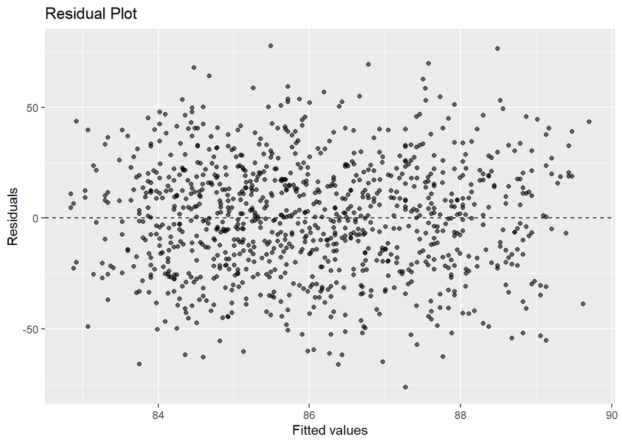

Residual plot for monthly spend regression model

```r
aug_spend <- augment(spend_lm)

ggplot(aug_spend, aes(x = .fitted, y = .resid)) +
  geom_point(alpha = 0.6) +
  geom_hline(yintercept = 0, linetype = "dashed") +
  labs(
    title = "Residual Plot",
    x = "Fitted values",
    y = "Residuals"
  )
```

There is no actual patterns all points are randomly scattered around 0.

## 7.3 Exercise 2 — Data splitting

Using the `customer_data` dataset:

1. Create a 70/30 stratified split on `churn`.
2. Verify that the churn rate is similar in both sets.
3. Check whether the distribution of `last_login_days` looks similar in training and testing.

### 7.3.1 Create a 70/30 stratified split on churn

```r
set.seed(123)

customer_split <- initial_split(
  customer_data,
  prop = 0.70,
  strata = churn
)

customer_train <- training(customer_split)
customer_test <- testing(customer_split)

nrow(customer_train)
```

```
[1] 699
```

```r
nrow(customer_test)
```

```
[1] 301
```

### 7.3.2 Verify churn rate in both sets

```r
train_churn <- customer_train |>
  count(churn) |>
  mutate(dataset = "Training", prop = n / sum(n))

test_churn <- customer_test |>
  count(churn) |>
  mutate(dataset = "Testing", prop = n / sum(n))

bind_rows(train_churn, test_churn) |>
  select(dataset, churn, n, prop) |>
  kable(digits = 4, caption = "Churn rate comparison for training and testing sets")
```

Churn rate comparison for training and testing sets

| dataset | churn | n | prop |
| --- | --- | --- | --- |
| Training | no | 441 | 0.6309 |
| Training | yes | 258 | 0.3691 |
| Testing | no | 190 | 0.6312 |
| Testing | yes | 111 | 0.3688 |

The churn rate should be similar in the training and testing sets because the split was stratified by `churn`.

### 7.3.3 Compare the distribution of last_login_days

```r
bind_rows(
  customer_train |> mutate(dataset = "Training"),
  customer_test |> mutate(dataset = "Testing")
) |>
  group_by(dataset) |>
  summarize(
    mean_last_login = mean(last_login_days),
    median_last_login = median(last_login_days),
    sd_last_login = sd(last_login_days),
    .groups = "drop"
  ) |>
  kable(digits = 2, caption = "Summary of last_login_days by dataset")
```

Summary of last_login_days by dataset

| dataset | mean_last_login | median_last_login | sd_last_login |
| --- | --- | --- | --- |
| Testing | 43.58 | 43 | 27.93 |
| Training | 46.20 | 46 | 26.63 |

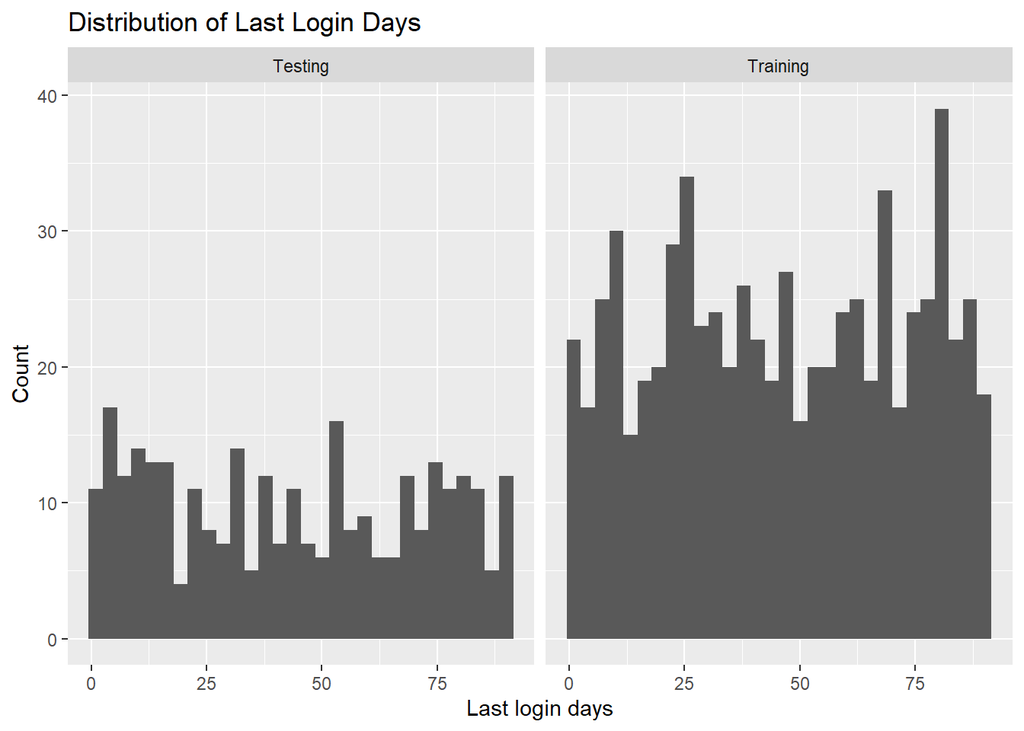

Distribution of last_login_days in training and testing sets

```r
tail_data <- bind_rows(
  customer_train |> mutate(dataset = "Training"),
  customer_test |> mutate(dataset = "Testing")
)

ggplot(tail_data, aes(x = last_login_days)) +
  geom_histogram(bins = 30) +
  facet_wrap(~ dataset) +
  labs(
    title = "Distribution of Last Login Days",
    x = "Last login days",
    y = "Count"
  )
```

The distributions of `last_login_days` should look similar across the training and testing sets. They may not be identical because random splitting creates some sampling differences but should be reasonably close.

## 7.4 Exercise 3 — Critical thinking

### 7.4.1 A colleague says: “I looked at the test set to understand the data better before modeling. I did not fit any models on it.” Is this a problem? Why or why not?

The test set is supposed to represent unseen data used only for final evaluation. Even if the colleague did not fit a model on it, looking at the test set may influence modeling decisions and create data leakage.

### 7.4.2 You are building a fraud detection model. Only 0.1% of transactions are fraudulent. Why is stratified splitting especially important here?

Stratified splitting is especially important because fraud cases are extremely rare. Without stratification, the training set might contain too few fraud cases or possibly none, this helps preserve the rare fraud cases in the datasets.

### 7.4.3 A model achieves 92% accuracy on the training set and 61% accuracy on the test set. What does this tell you? What would you do next?

This suggests the model is overfitting performing well on the training data but does not transfer well to new data. I would simplify the model, use cross-validation, check for data leakage, tune hyperparameters, and consider better feature engineering.

# 8 Appendix

## 8.1 Published report on GitHub Pages

[Published Report](https://brahhmen55.github.io/IBM6300/)

## 8.2 GitHub Repository

[GitHub Repository](https://github.com/Brahhmen55/IBM6300)